# Health and Economic cost of Storm Damage

23 August 2015

## Synopsis

In this report we aim to identify storms and severe weather events that cause the most harm to people and the greatest economic consequences. The data are from the U.S. National Oceanic and Atmospheric Administration’s (NOAA) storm database. Below I will show which events cause the most deaths and injuries and which events have the most financial impact. This analysis sets out to be reproducible.

## Data Processing

In preparation for the analysis we must load the data and libraries as well as set our options for R.

```r
library(knitr)
opts_chunk$set(echo = TRUE, results = 'hold')
knitr::opts_chunk$set(fig.path = 'figure/')
library(dplyr)
library(ggplot2)
library(tidyr)
options(scipen=9)
```

The data is hosted on the internet and was downloaded on Fri Aug 21 22:00:34 2015. The code below will download the data if that file can’t be found in the data directory. Once the data is downloaded we will read it into a variable storms. This large dataset will be cached and will only be read again if something changes in the code.

```r
#Create a data directory if one doesn't already exist
if (!file.exists("data")){
    dir.create("data")
}

#Store the file URL
fileUrl <- "https://d396qusza40orc.cloudfront.net/repdata%2Fdata%2FStormData.csv.bz2"

#If the file doesn't exist in the data directory then download it
if(!file.exists(".\\data\\repdata-data-StormData.csv.bz2")){
    download.file(fileUrl, destfile = ".\\data\\repdata-data-StormData.csv.bz2",
                  mode = "wb")
    dateDownloaded <- date()
    dateDownloaded
}

#Read data into the variable storms
storms <- read.csv(".\\data\\repdata-data-StormData.csv.bz2")
```

Let’s get a feel for the data.

```r
str(storms)
dimStorms <- dim(storms) #calculate dimensions for discussion
```

```
## 'data.frame':    902297 obs. of  37 variables:
##  $ STATE__   : num  1 1 1 1 1 1 1 1 1 1 ...
##  $ BGN_DATE  : Factor w/ 16335 levels "1/1/1966 0:00:00",..: 6523 6523 4242 11116 2224 2224 2260 383 3980 3980 ...
##  $ BGN_TIME  : Factor w/ 3608 levels "00:00:00 AM",..: 272 287 2705 1683 2584 3186 242 1683 3186 3186 ...
##  $ TIME_ZONE : Factor w/ 22 levels "ADT","AKS","AST",..: 7 7 7 7 7 7 7 7 7 7 ...
##  $ COUNTY    : num  97 3 57 89 43 77 9 123 125 57 ...
##  $ COUNTYNAME: Factor w/ 29601 levels "","5NM E OF MACKINAC BRIDGE TO PRESQUE ISLE LT MI",..: 13513 1873 4598 10592 4372 10094 1973 23873 24418 4598 ...
##  $ STATE     : Factor w/ 72 levels "AK","AL","AM",..: 2 2 2 2 2 2 2 2 2 2 ...
##  $ EVTYPE    : Factor w/ 985 levels "   HIGH SURF ADVISORY",..: 834 834 834 834 834 834 834 834 834 834 ...
##  $ BGN_RANGE : num  0 0 0 0 0 0 0 0 0 0 ...
##  $ BGN_AZI   : Factor w/ 35 levels "","  N"," NW",..: 1 1 1 1 1 1 1 1 1 1 ...
##  $ BGN_LOCATI: Factor w/ 54429 levels "","- 1 N Albion",..: 1 1 1 1 1 1 1 1 1 1 ...
##  $ END_DATE  : Factor w/ 6663 levels "","1/1/1993 0:00:00",..: 1 1 1 1 1 1 1 1 1 1 ...
##  $ END_TIME  : Factor w/ 3647 levels ""," 0900CST",..: 1 1 1 1 1 1 1 1 1 1 ...
##  $ COUNTY_END: num  0 0 0 0 0 0 0 0 0 0 ...
```

[output cut: 23 more lines]

There are 902297 observations and 37 different variables collected about those observations. I know that some of the storm and big weather events held in the EVTYPE column appear with different capitalization. So we can group the events together better we will make them all uppercase.

```r
#make events all uppercase
storms$EVTYPE <- toupper(storms$EVTYPE)
```

## Results

### Events most harmful with respect to population health

The data collection is a mix of events which caused injuries or fatalities or caused property damage or a mixture of both. Focusing on events that were harmful to health the data below is going to be restricted to only those events where someone was injured or killed.

```r
library(dplyr)
#take only those events that cause injuries or fatalities
#Keep only the columns concerned with the type of storm number,
#the number of fatalities and the number of injuries
harmful <- storms %>%
    select(EVTYPE,
           FATALITIES,
           INJURIES) %>%

    #Only take records where there was at least one fatality or injury
    filter(FATALITIES > 0 |
               INJURIES > 0) %>%

    #Put all similar storms together
    group_by(EVTYPE) %>%

    #Add up the total deaths and injuries for each type of weather event
    summarise(Fatalities = sum(FATALITIES),
              Injuries = sum(INJURIES)) %>%

    #Order by the most to least deaths
    arrange(desc(Fatalities), desc(Injuries))

#Show the events that cause the most harm
head(harmful, 10)
```

```
## Source: local data frame [10 x 3]
##
##            EVTYPE Fatalities Injuries
## 1         TORNADO       5633    91346
## 2  EXCESSIVE HEAT       1903     6525
## 3     FLASH FLOOD        978     1777
## 4            HEAT        937     2100
## 5       LIGHTNING        816     5230
## 6       TSTM WIND        504     6957
## 7           FLOOD        470     6789
## 8     RIP CURRENT        368      232
## 9       HIGH WIND        248     1137
## 10      AVALANCHE        224      170
```

Events that caused death or injury are gathered by event type in the above table and the total number of Fatalities and Injuries for that event are added across all the states and different storms events. We can see Tornado’s caused the most deaths when added together.

Let’s see the top ten events plotted with Fatalities next to Injuries.

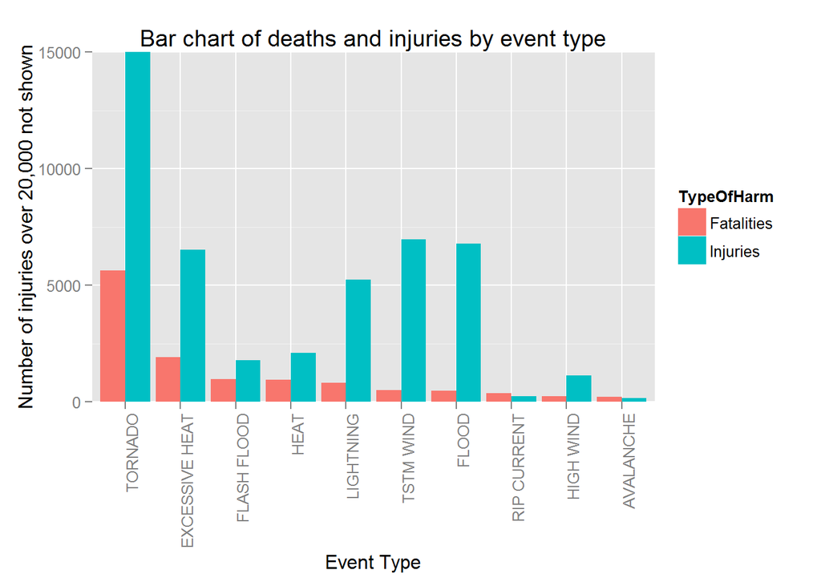

```r
#Keep only the 1o most harmful
harmful10 <- harmful[1:10, ]

#Change the format from wide to long for ease of plotting
harmfultall <- gather(harmful10, TypeOfHarm, Numbers, Fatalities:Injuries)

#Order the events from most to least deaths
harmfultall$EVTYPE <- factor(harmfultall$EVTYPE,
                           levels = harmful10$EVTYPE, ordered = TRUE)

#Plot a barchart
g <- ggplot(data = harmfultall, aes(x = EVTYPE, y = Numbers, fill = TypeOfHarm))
g <- g + geom_bar(stat="identity", position="dodge")
g <- g + coord_cartesian(ylim=c(0,15000))
g <- g + theme(axis.text.x = element_text(angle = 90, hjust = 1))
g <- g + labs(title = "Bar chart of deaths and injuries by event type")
g <- g + labs(x = "Event Type", y = "Number of injuries over 20,000 not shown")

g
```

Tornado’s actually caused 91346 injuries however this figure is not shown on the graph to allow us to zoom in on other features such as the comparison of events causing relativity less damage to health. As can be seen the top 3 events causing death are Tornado, Excessive Heat and flash flood. Further down the list are Lightning, TSTM Wind and Flood which have caused less deaths but over 5000 injuries each.

### Events with the greatest economic consequences

Economic consequences can be difficult to estimate however the data has been put together with a breakdown of the estimated value of property damage and estimated value of damage to crops. If you require further details of a particular event along with possible notes on how reliable the costings of damage see the Remarks column in the full data set.

Below we identify events where there is either property or crop damage. We convert the short hand “K” for thousands and “B” for billions to allow us to calculate the Property damage costs, crop damage cost and total cost in US Dollars.

```r
#Set up variable to convet short hand to dollar amounts
convertPROPDMGEXP <- data.frame(PROPDMGEXP = c("H", "K", "M", "B", ""),
                           PROPDMGfactor = c(100, 1000, 1000000, 1000000000, 0))
convertCROPDMGEXP <- data.frame(CROPDMGEXP = c("H", "K", "M", "B", ""),
                                CROPDMGfactor = c(100, 1000, 1000000, 1000000000, 0))

#Select only the columns we need for the analysis including
#PROPDMG: value of property damage, PROPDMGEXP: the unit of value
#CROPDMG: value of crop damage, cROPDMGEXP: the unit of value
damage <- select(storms,
                EVTYPE,
                PROPDMG,
                PROPDMGEXP,
                CROPDMG,
                CROPDMGEXP) %>%

    #Convert all the units to upper case for easy comparison
    mutate_each(funs(toupper), PROPDMGEXP, CROPDMGEXP) %>%

    #Keep entries with correctly filled in units
    filter(PROPDMGEXP %in% c("H", "K", "M", "B") |
                         CROPDMGEXP %in% c("H", "K", "M", "B")) %>%

    #Keep entries that have both property and crop units entered correctly
    filter(PROPDMGEXP %in% c("H", "K", "M", "B", "") &
                     CROPDMGEXP %in% c("H", "K", "M", "B", "")) %>%

    #Unit in dollars
    left_join(convertPROPDMGEXP, c("PROPDMGEXP")) %>%
    left_join(convertCROPDMGEXP, c("CROPDMGEXP")) %>%

    #calulate the dollar amounts for property, crop and all
    mutate(PropertyCosts = PROPDMG * PROPDMGfactor,
           CropCosts = CROPDMG * CROPDMGfactor,
           TotalDamage = PropertyCosts + CropCosts) %>%

    #Order by the highest total value
    arrange(desc(TotalDamage), desc(PropertyCosts), desc(CropCosts))
```

The top events ordered by most expensive damage are

```r
head(damage[, c(1, 8, 9, 10)], 10)
```

```
##               EVTYPE PropertyCosts  CropCosts  TotalDamage
## 1              FLOOD  115000000000   32500000 115032500000
## 2        STORM SURGE   31300000000          0  31300000000
## 3  HURRICANE/TYPHOON   16930000000          0  16930000000
## 4        STORM SURGE   11260000000          0  11260000000
## 5  HURRICANE/TYPHOON   10000000000          0  10000000000
## 6        RIVER FLOOD    5000000000 5000000000  10000000000
## 7  HURRICANE/TYPHOON    5880000000 1510000000   7390000000
## 8  HURRICANE/TYPHOON    7350000000          0   7350000000
## 9  HURRICANE/TYPHOON    5420000000  285000000   5705000000
## 10    TROPICAL STORM    5150000000          0   5150000000
```

We can see that a single flood cost around $115 Billion dollars. Let’s take a look at the combined Total damage costs for all events of the same type. First we need to add these costs up.

```r
#add all the damage costs for each event type
damageEVTYPE <- damage %>%

    #keep only the totals in dollars
    select(EVTYPE, PropertyCosts, CropCosts, TotalDamage) %>%

    #group by Event type
    group_by(EVTYPE) %>%

    #Add up the costs for each type
    summarize(PropertyCosts = sum(PropertyCosts),
              CropCosts = sum(CropCosts),
        TotalDamage = sum(TotalDamage)) %>%

    #Order starting at the most expensive
    arrange(desc(TotalDamage))

#Show the top ten event types
head(damageEVTYPE, 10)
```

```
## Source: local data frame [10 x 4]
##
##               EVTYPE PropertyCosts   CropCosts  TotalDamage
## 1              FLOOD  144657709800  5661968450 150319678250
## 2  HURRICANE/TYPHOON   69305840000  2607872800  71913712800
## 3            TORNADO   56936985480   364950110  57301935590
## 4        STORM SURGE   43323536000        5000  43323541000
## 5               HAIL   15732262220  3000954450  18733216670
## 6        FLASH FLOOD   16140811510  1420727100  17561538610
## 7            DROUGHT    1046106000 13972566000  15018672000
## 8          HURRICANE   11868319010  2741910000  14610229010
## 9        RIVER FLOOD    5118945500  5029459000  10148404500
## 10         ICE STORM    3944927810  5022110000   8967037810
```

After we have added up all the costs Flood still costs the most. Even though we saw earlier a storm surge was the second most expensive single event when we add up the costs for all such events we find Hurricane/Typhoon is the second largest in terms of expense.

Here is the same data in a graph.

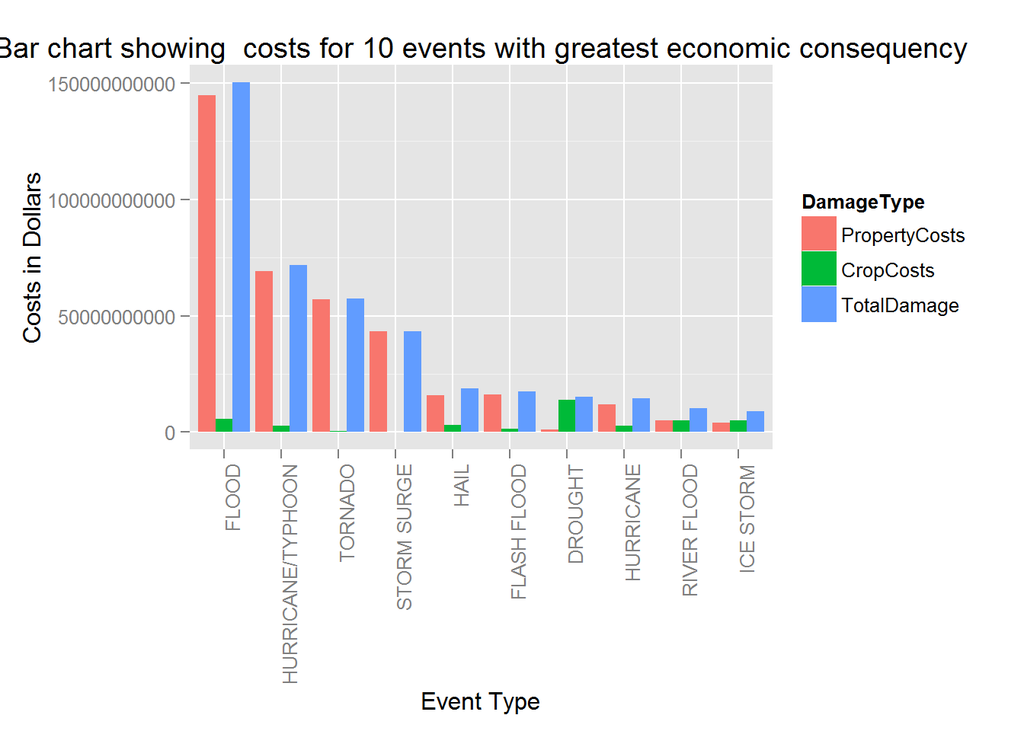

```r
#Take top 10 most expensive event types
damageTotalTop10 <- damageEVTYPE[1:10, ]

#Order events on the graph from highest total expense
EVTYPETop10 <- damageEVTYPE[1:10, ]$EVTYPE
damageTotalTop10$EVTYPE <- factor(damageTotalTop10$EVTYPE,
                                  levels = EVTYPETop10, ordered = TRUE)

#Convert to wide format to show both property and crop costs
damageTotalTop10 <- gather(damageTotalTop10, DamageType, Dollars, PropertyCosts:TotalDamage)

#plot a bar graph
g <- ggplot(data = damageTotalTop10, aes(x = EVTYPE, y = Dollars, fill = DamageType))
g <- g + geom_bar(stat="identity", position="dodge")
g <- g + theme(axis.text.x = element_text(angle = 90, hjust = 1))
g <- g + labs(title = "Bar chart showing  costs for 10 events with greatest economic consequency")
g <- g + labs(x = "Event Type", y = "Costs in Dollars")

g
```

We can see on the graph that the largest cost is the combined total for floods. The first four costs in decreasing cost come from Flood, Hurricane/Typhoon, Tornado and Storm Surge with the expensive dropping off. After that the cost associated with Hail, Flashflood, Drought and Hurricane are more comparable.

### Limitations

There is user error involved in submitting these storm events into the database. More work could be done to group like events together and clean up some spelling mistakes and alternative event type names to get an even clearer picture of the most life threatening and costly events.